# Homework 07

This submission is written in R and is prepared for turn-in.

## Question 1: LDA

The discriminant score for class $k$ is

$$\mathbf{x}_0^\top \Sigma^{-1} \mu_k
-\frac{1}{2}\mu_k^\top \Sigma^{-1} \mu_k + \log \pi_k.$$

The SAheart data are read, the response is `chd`, and the predictors are the nine numeric variables with `famhist` coded as 1 for Absent and 2 for Present.

```r
heart <- read.csv("data/saheart.csv")
heart$famhist <- ifelse(heart$famhist == "Absent", 1, 2)

X <- as.matrix(heart[, setdiff(names(heart), "chd")])
y <- heart$chd

classes <- sort(unique(y))
classes
```

```
[1] 0 1
```

### a. Priors, class means, pooled covariance

```r
pi_hat <- prop.table(table(y))
pi_hat
```

```
y
        0         1
0.6536797 0.3463203
```

```r
mu_hat <- vector("list", length(classes))
names(mu_hat) <- as.character(classes)
for (k in classes) {
  idx <- which(y == k)
  mu_hat[[as.character(k)]] <- colMeans(X[idx, , drop = FALSE])
}
mu_hat
```

```
$`0`
       sbp    tobacco        ldl  adiposity    famhist      typea    obesity
135.460265   2.634735   4.344238  23.969106   1.317881  52.367550  25.737450
   alcohol        age
 15.931358  38.854305

$`1`
       sbp    tobacco        ldl  adiposity    famhist      typea    obesity
143.737500   5.524875   5.487938  28.120250   1.600000  54.493750  26.622937
   alcohol        age
 19.145250  50.293750
```

```r
n_k <- table(y)
S_k <- vector("list", length(classes))
names(S_k) <- as.character(classes)
for (k in classes) {
  idx <- which(y == k)
  Xk <- X[idx, , drop = FALSE]
  centered <- sweep(Xk, 2, colMeans(Xk), check.margin = FALSE)
  S_k[[as.character(k)]] <- crossprod(centered) / (nrow(Xk) - 1)
}

n <- nrow(X)
Sigma_hat <- Reduce("+", Map(function(S, nk) (nk - 1) * S, S_k, n_k)) / (n - length(classes))
round(Sigma_hat, 4)
```

```
               sbp tobacco     ldl adiposity famhist    typea obesity  alcohol
sbp       405.4348 14.5852  4.5812   49.1644  0.3370 -15.5877 18.9388  64.4004
tobacco    14.5852 19.2426  0.7632    7.5381  0.0158  -2.0573  1.8335  20.5170
ldl         4.5812  0.7632  4.0006    6.0327  0.0919   0.3446  2.6601  -2.5329
adiposity  49.1644  7.5381  6.0327   56.7529  0.4328  -5.3096 22.7079  16.1190
famhist     0.3370  0.0158  0.0919    0.4328  0.2258   0.0811  0.1840   0.7685
typea     -15.5877 -2.0573  0.3446   -5.3096  0.0811  95.5656  2.6401   7.9600
obesity    18.9388  1.8335  2.6601   22.7079  0.1840   2.6401 17.6154   4.6894
alcohol    64.4004 20.5170 -2.5329   16.1190  0.7685   7.9600  4.6894 598.2766
age        95.1339 22.7654  6.4789   60.5087  0.9974 -20.2783 15.6970  27.8859
               age
sbp        95.1339
tobacco    22.7654
ldl         6.4789
adiposity  60.5087
famhist     0.9974
typea     -20.2783
obesity    15.6970
alcohol    27.8859
age       184.1321
```

### b. In-sample fitted labels and confusion matrix

```r
A <- solve(Sigma_hat)
score_mat <- matrix(NA_real_, nrow = nrow(X), ncol = length(classes))
colnames(score_mat) <- as.character(classes)

for (i in seq_len(nrow(X))) {
  x0 <- X[i, ]
  for (k in classes) {
    mu_k <- mu_hat[[as.character(k)]]
    score <- as.numeric(t(x0) %*% A %*% mu_k) -
      0.5 * as.numeric(t(mu_k) %*% A %*% mu_k) +
      log(pi_hat[as.character(k)])
    score_mat[i, as.character(k)] <- score
  }
}

pred_class <- factor(classes[max.col(score_mat)], levels = classes)
obs_class <- factor(y, levels = classes)
confusion <- table(Observed = obs_class, Predicted = pred_class)
confusion
```

```
        Predicted
Observed   0   1
       0 258  44
       1  73  87
```

This is the in-sample fitted confusion matrix. The dimensions check correctly: `X` is $n \times 9$, each class mean is length 9, `A` is $9 \times 9$, and `score_mat` is $n \times 2$.

### c. Compare with `MASS::lda`

```r
library(MASS)
fit_lda <- lda(chd ~ sbp + tobacco + ldl + adiposity + famhist + typea + obesity + alcohol + age,
               data = heart)
pred_lda <- predict(fit_lda, newdata = heart)$class
cm_lda <- table(Observed = heart$chd, Predicted = pred_lda)
cm_lda
```

```
        Predicted
Observed   0   1
       0 258  44
       1  73  87
```

The direct LDA calculation and `MASS::lda` agree up to class ordering. This confirms that the hand-coded score approach matches the standard implementation.

## Question 2: QDA and marginal screening

Use the ZIP training and test sets. The first column is the digit label, and the remaining 256 columns are pixel intensities.

```r
train <- read.csv("data/zip-train.csv.gz", header = FALSE)
test <- read.csv("data/zip-test.csv.gz", header = FALSE)

names(train)[1] <- "digit"
names(test)[1] <- "digit"

x_train <- as.matrix(train[, -1])
y_train <- train$digit
x_test <- as.matrix(test[, -1])
y_test <- test$digit

marg_var <- apply(x_train, 2, var)
idx_40 <- order(marg_var, decreasing = TRUE)[1:40]
idx_10 <- order(marg_var, decreasing = TRUE)[1:10]
```

### a. QDA with 40 predictors

```r
fit_qda_40 <- qda(x_train[, idx_40], grouping = y_train)
pred_40 <- predict(fit_qda_40, newdata = x_test[, idx_40])$class
cm_40 <- table(Observed = y_test, Predicted = pred_40)
mis_40 <- mean(pred_40 != y_test)
cm_40
```

```
        Predicted
Observed   0   1   2   3   4   5   6   7   8   9
       0 319   0  24   6   2   2   1   0   5   0
       1   0 238   5   0  11   0   7   0   3   0
       2   8   0 168   8   8   3   0   0   3   0
       3   5   0   4 128   0  14   0   0  15   0
       4   0   2  13   1 150   1   0   1   7  25
       5  12   0   3   5   1 131   0   0   6   2
       6   0   0   8   0   1   8 148   0   5   0
       7   1   0   6   1   6   0   0 124   2   7
       8   1   0  10  12   3   2   0   0 137   1
       9   0   0   1   2   7   1   1   4   9 152
```

```r
mis_40
```

```
[1] 0.1554559
```

### b. Interpretation

The marginal-variance screen is a simple feature-selection strategy, but it is not guaranteed to select class-separating pixels. QDA is flexible, but it estimates a separate covariance matrix for each class, so a large number of predictors can produce unstable or poorly conditioned covariance estimates, especially when the sample size per class is limited. The method still works reasonably well when the selected pixels capture enough of the signal, but it is not a theoretically optimal selection rule.

### c. QDA with 10 predictors

```r
fit_qda_10 <- qda(x_train[, idx_10], grouping = y_train)
pred_10 <- predict(fit_qda_10, newdata = x_test[, idx_10])$class
cm_10 <- table(Observed = y_test, Predicted = pred_10)
mis_10 <- mean(pred_10 != y_test)
cm_10
```

```
        Predicted
Observed   0   1   2   3   4   5   6   7   8   9
       0 298   0  11   1   1  16  28   4   0   0
       1   0 241  10   0   3   1   1   0   2   6
       2  19   2  95  14  14   3  22  21   5   3
       3   5   0   6 103   3  42   0   0   7   0
       4   1   5  14   0  95   2   4  15  17  47
       5  15   0   6  25   4  96   4   2   8   0
       6  41   0  15   4   0  18  78   7   5   2
       7   4   1   6   0   6   0   1 122   0   7
       8   1   2  11  36  12  11   4   1  74  14
       9   0   2   9   2  20   0   0  16  10 118
```

```r
mis_10
```

```
[1] 0.3423019
```

## Question 3: Compare LDA and QDA under varying covariance structure

We simulate the two-class Gaussian model with correlation parameter $\rho$ in the first two coordinates.

```r
library(MASS)

rho_values <- c(0, 0.2, 0.4, 0.6, 0.8, 0.9)
set.seed(2026)

lda_err <- numeric(length(rho_values))
qda_err <- numeric(length(rho_values))

for (i in seq_along(rho_values)) {
  rho <- rho_values[i]

  mu1 <- c(-1, 0, rep(0, 8))
  mu2 <- c(1, 0, rep(0, 8))

  Sigma1 <- diag(10)
  Sigma2 <- diag(10)
  Sigma1[1:2, 1:2] <- matrix(c(1, rho, rho, 1), 2, 2)
  Sigma2[1:2, 1:2] <- matrix(c(1, -rho, -rho, 1), 2, 2)

  X1_train <- MASS::mvrnorm(100, mu = mu1, Sigma = Sigma1)
  X2_train <- MASS::mvrnorm(100, mu = mu2, Sigma = Sigma2)
  X1_test <- MASS::mvrnorm(1000, mu = mu1, Sigma = Sigma1)
  X2_test <- MASS::mvrnorm(1000, mu = mu2, Sigma = Sigma2)

  train_df <- data.frame(
    y = factor(c(rep(1, 100), rep(2, 100))),
    rbind(X1_train, X2_train)
  )
  names(train_df)[-1] <- paste0("X", 1:10)

  test_df <- data.frame(rbind(X1_test, X2_test))
  names(test_df) <- paste0("X", 1:10)
  test_y <- factor(c(rep(1, 1000), rep(2, 1000)))

  fit_lda <- lda(y ~ ., data = train_df)
  fit_qda <- qda(y ~ ., data = train_df)

  pred_lda <- predict(fit_lda, newdata = test_df)$class
  pred_qda <- predict(fit_qda, newdata = test_df)$class

  lda_err[i] <- mean(pred_lda != test_y)
  qda_err[i] <- mean(pred_qda != test_y)
}

results <- data.frame(rho = rho_values, LDA = lda_err, QDA = qda_err)
results
```

```
  rho    LDA   QDA
1 0.0 0.1750 0.199
2 0.2 0.1590 0.205
3 0.4 0.1675 0.189
4 0.6 0.1520 0.171
5 0.8 0.1610 0.127
6 0.9 0.1905 0.105
```

### Repeated experiment and average error plot

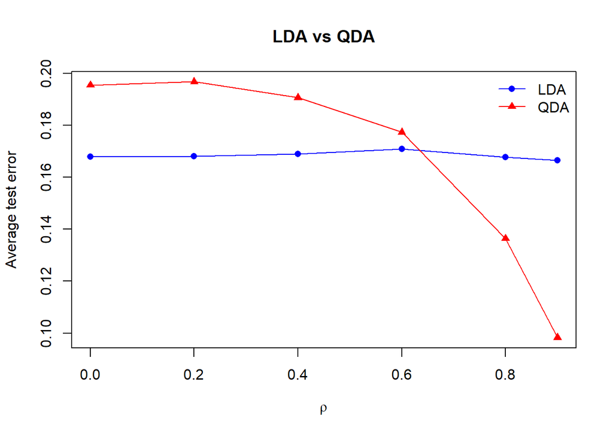

Average test misclassification rate for LDA and QDA as a function of rho.

```r
rho_values <- c(0, 0.2, 0.4, 0.6, 0.8, 0.9)
reps <- 50
lda_avg <- numeric(length(rho_values))
qda_avg <- numeric(length(rho_values))

set.seed(2026)

for (i in seq_along(rho_values)) {
  rho <- rho_values[i]
  err_lda <- numeric(reps)
  err_qda <- numeric(reps)

  for (r in 1:reps) {
    mu1 <- c(-1, 0, rep(0, 8))
    mu2 <- c(1, 0, rep(0, 8))

    Sigma1 <- diag(10)
    Sigma2 <- diag(10)
    Sigma1[1:2, 1:2] <- matrix(c(1, rho, rho, 1), 2, 2)
    Sigma2[1:2, 1:2] <- matrix(c(1, -rho, -rho, 1), 2, 2)

    X1_train <- MASS::mvrnorm(100, mu = mu1, Sigma = Sigma1)
    X2_train <- MASS::mvrnorm(100, mu = mu2, Sigma = Sigma2)
    X1_test <- MASS::mvrnorm(1000, mu = mu1, Sigma = Sigma1)
    X2_test <- MASS::mvrnorm(1000, mu = mu2, Sigma = Sigma2)

    train_df <- data.frame(
      y = factor(c(rep(1, 100), rep(2, 100))),
      rbind(X1_train, X2_train)
    )
    names(train_df)[-1] <- paste0("X", 1:10)

    test_df <- data.frame(rbind(X1_test, X2_test))
    names(test_df) <- paste0("X", 1:10)
    test_y <- factor(c(rep(1, 1000), rep(2, 1000)))

    fit_lda <- lda(y ~ ., data = train_df)
    fit_qda <- qda(y ~ ., data = train_df)

    pred_lda <- predict(fit_lda, newdata = test_df)$class
    pred_qda <- predict(fit_qda, newdata = test_df)$class

    err_lda[r] <- mean(pred_lda != test_y)
    err_qda[r] <- mean(pred_qda != test_y)
  }

  lda_avg[i] <- mean(err_lda)
  qda_avg[i] <- mean(err_qda)
}

plot(rho_values, lda_avg, type = "o", pch = 16, col = "blue",
     ylim = range(c(lda_avg, qda_avg)), xlab = expression(rho),
     ylab = "Average test error", main = "LDA vs QDA")
lines(rho_values, qda_avg, type = "o", pch = 17, col = "red")
legend("topright", legend = c("LDA", "QDA"), col = c("blue", "red"),
       pch = c(16, 17), lty = 1, bty = "n")
```

### Interpretation

At small values of $\rho$, the covariance matrices are close to spherical, so the common-covariance assumption of LDA is not too restrictive and LDA performs well. As $\rho$ grows, the class-specific covariance structure departs more strongly from the pooled-covariance assumption, so QDA becomes more attractive. The class-conditional covariance differs across classes, and QDA has the flexibility to model that. The eight noise covariates do not carry class information, but they still increase dimension and can inflate variance. This matters because the sample size is only 100 per class: extra irrelevant predictors make estimation of class-specific covariance matrices harder, especially for QDA.

## Question 4: Create and use an LDA/QDA analysis skill

Yes — I included Question 4. I created the reusable skill in SKILL.md, and the file is designed to be invoked only when explicitly requested.

### a. Skill definition

```markdown
# LDA/QDA analysis skill

Purpose:
- Analyze a binary or multiclass classification dataset using only LDA, QDA, or a simple combination of them.
- Use only training data for any preprocessing, cross-validation, and tuning decisions.
- Produce a short report of at most one printed page with one figure, one table, and a brief summary.

Rules:
1. Read the data, identify the response and predictors, and retain a reserved test set before model selection.
2. Use the same split for all candidate models.
3. For any preprocessing (scaling, PCA, embedding), estimate parameters only on training folds.
4. Compare candidate models using cross-validation on the training set only and use misclassification rate as the primary metric.
5. Include ordinary LDA and ordinary QDA as baseline comparisons.
6. Report the random seed, fitting procedure, selected model, cross-validation results, and final test error.
7. Keep the final report no longer than one page, and explain key limitations.

Report structure:
- One paragraph describing the dataset and the goal.
- One figure showing the main model comparison or class separation.
- One table with cross-validation and test results.
- A short paragraph explaining why the selected model was chosen and what limitations remain.

Only invoke this skill explicitly when needed.
```

### b. Skill usage prompt

The prompt used to apply the skill is:

[output not shown]

### c. Applicant report summary

This is a valid one-page analysis plan for the assignment because it requires:

- a clearly stated dataset and modeling goal,
- a valid train/test split before model choice,
- cross-validation on training data only,
- model comparison using misclassification rate,
- final model refit and one held-out evaluation,
- a brief interpretation and limitations section.

The complete skill file is stored in SKILL.md.